# Risk Factor Analysis

## Outcome Variable

**Outcome Variable:** swasted

## Predictor Variables

**Intervention Variable:** vagbrth

**Adjustment Set:**

- arm
- sex
- W_mage
- meducyrs
- feducyrs
- hhwealth_quart
- W_mhtcm
- W_mwtkg
- W_mbmi
- single
- W_nrooms
- brthmon
- W_parity
- impfloor
- delta_W_mage
- delta_meducyrs
- delta_feducyrs
- delta_hhwealth_quart
- delta_W_mhtcm
- delta_W_mwtkg
- delta_W_mbmi
- delta_single
- delta_W_nrooms
- delta_brthmon
- delta_W_parity
- delta_impfloor

## Stratifying Variables

The analysis was stratified on these variable(s):

- agecat
- studyid
- country

## Data Summary

| agecat | studyid | country | vagbrth | swasted | n_cell | n |
| --- | --- | --- | --- | --- | --- | --- |
| Birth | CMC-V-BCS-2002 | INDIA | 0 | 0 | 10 | 86 |
| Birth | CMC-V-BCS-2002 | INDIA | 0 | 1 | 0 | 86 |
| Birth | CMC-V-BCS-2002 | INDIA | 1 | 0 | 75 | 86 |
| Birth | CMC-V-BCS-2002 | INDIA | 1 | 1 | 1 | 86 |
| Birth | IRC | INDIA | 0 | 0 | 52 | 343 |
| Birth | IRC | INDIA | 0 | 1 | 14 | 343 |
| Birth | IRC | INDIA | 1 | 0 | 237 | 343 |
| Birth | IRC | INDIA | 1 | 1 | 40 | 343 |
| Birth | JiVitA-3 | BANGLADESH | 0 | 0 | 483 | 17985 |
| Birth | JiVitA-3 | BANGLADESH | 0 | 1 | 17 | 17985 |
| Birth | JiVitA-3 | BANGLADESH | 1 | 0 | 17154 | 17985 |
| Birth | JiVitA-3 | BANGLADESH | 1 | 1 | 331 | 17985 |
| Birth | JiVitA-4 | BANGLADESH | 0 | 0 | 70 | 2395 |
| Birth | JiVitA-4 | BANGLADESH | 0 | 1 | 1 | 2395 |
| Birth | JiVitA-4 | BANGLADESH | 1 | 0 | 2294 | 2395 |
| Birth | JiVitA-4 | BANGLADESH | 1 | 1 | 30 | 2395 |
| Birth | NIH-Crypto | BANGLADESH | 0 | 0 | 179 | 465 |
| Birth | NIH-Crypto | BANGLADESH | 0 | 1 | 5 | 465 |
| Birth | NIH-Crypto | BANGLADESH | 1 | 0 | 257 | 465 |
| Birth | NIH-Crypto | BANGLADESH | 1 | 1 | 24 | 465 |
| Birth | PROBIT | BELARUS | 0 | 0 | 1499 | 13817 |
| Birth | PROBIT | BELARUS | 0 | 1 | 92 | 13817 |
| Birth | PROBIT | BELARUS | 1 | 0 | 11399 | 13817 |
| Birth | PROBIT | BELARUS | 1 | 1 | 827 | 13817 |
| Birth | PROVIDE | BANGLADESH | 0 | 0 | 104 | 532 |
| Birth | PROVIDE | BANGLADESH | 0 | 1 | 4 | 532 |
| Birth | PROVIDE | BANGLADESH | 1 | 0 | 415 | 532 |
| Birth | PROVIDE | BANGLADESH | 1 | 1 | 9 | 532 |
| Birth | ZVITAMBO | ZIMBABWE | 0 | 0 | 1016 | 12814 |
| Birth | ZVITAMBO | ZIMBABWE | 0 | 1 | 84 | 12814 |

[output cut: 74 more lines]

The following strata were considered:

- agecat: 24 months, studyid: CMC-V-BCS-2002, country: INDIA
- agecat: 24 months, studyid: IRC, country: INDIA
- agecat: 24 months, studyid: JiVitA-3, country: BANGLADESH
- agecat: 24 months, studyid: JiVitA-4, country: BANGLADESH
- agecat: 24 months, studyid: NIH-Crypto, country: BANGLADESH
- agecat: 24 months, studyid: PROBIT, country: BELARUS
- agecat: 24 months, studyid: PROVIDE, country: BANGLADESH
- agecat: 24 months, studyid: TanzaniaChild2, country: TANZANIA, UNITED REPUBLIC OF
- agecat: 24 months, studyid: ZVITAMBO, country: ZIMBABWE
- agecat: 6 months, studyid: CMC-V-BCS-2002, country: INDIA
- agecat: 6 months, studyid: IRC, country: INDIA
- agecat: 6 months, studyid: JiVitA-3, country: BANGLADESH
- agecat: 6 months, studyid: JiVitA-4, country: BANGLADESH
- agecat: 6 months, studyid: NIH-Crypto, country: BANGLADESH
- agecat: 6 months, studyid: PROBIT, country: BELARUS
- agecat: 6 months, studyid: PROVIDE, country: BANGLADESH
- agecat: 6 months, studyid: TanzaniaChild2, country: TANZANIA, UNITED REPUBLIC OF
- agecat: 6 months, studyid: ZVITAMBO, country: ZIMBABWE
- agecat: Birth, studyid: CMC-V-BCS-2002, country: INDIA
- agecat: Birth, studyid: IRC, country: INDIA
- agecat: Birth, studyid: JiVitA-3, country: BANGLADESH
- agecat: Birth, studyid: JiVitA-4, country: BANGLADESH
- agecat: Birth, studyid: NIH-Crypto, country: BANGLADESH
- agecat: Birth, studyid: PROBIT, country: BELARUS
- agecat: Birth, studyid: PROVIDE, country: BANGLADESH
- agecat: Birth, studyid: ZVITAMBO, country: ZIMBABWE

### Dropped Strata

Some strata were dropped due to rare outcomes:

- agecat: Birth, studyid: CMC-V-BCS-2002, country: INDIA
- agecat: Birth, studyid: JiVitA-4, country: BANGLADESH
- agecat: Birth, studyid: PROVIDE, country: BANGLADESH
- agecat: 6 months, studyid: CMC-V-BCS-2002, country: INDIA
- agecat: 6 months, studyid: IRC, country: INDIA
- agecat: 6 months, studyid: JiVitA-4, country: BANGLADESH
- agecat: 6 months, studyid: NIH-Crypto, country: BANGLADESH
- agecat: 6 months, studyid: PROBIT, country: BELARUS
- agecat: 6 months, studyid: PROVIDE, country: BANGLADESH
- agecat: 6 months, studyid: TanzaniaChild2, country: TANZANIA, UNITED REPUBLIC OF
- agecat: 24 months, studyid: CMC-V-BCS-2002, country: INDIA
- agecat: 24 months, studyid: IRC, country: INDIA
- agecat: 24 months, studyid: NIH-Crypto, country: BANGLADESH
- agecat: 24 months, studyid: PROBIT, country: BELARUS
- agecat: 24 months, studyid: PROVIDE, country: BANGLADESH
- agecat: 24 months, studyid: TanzaniaChild2, country: TANZANIA, UNITED REPUBLIC OF
- agecat: 24 months, studyid: ZVITAMBO, country: ZIMBABWE

## Methods Detail

We’re interested in the causal parameters $E[Y_a]$ for all values of $a \in \mathcal{A}$. These parameters represent the mean outcome if, possibly contrary to fact, we intervened to set all units to have $A=a$. Under the randomization and positivity assumptions, these are identified by the statistical parameters $\psi_a=E_W[E_{Y|A,W}(Y|A=a,W)]$. In addition, we’re interested in the mean of $Y$, $E[Y]$ under no intervention (the observed mean). We will estimate these parameters by using SuperLearner to fit the relevant likelihood factors – $E_{Y|A,W}(Y|A=a,W)$ and $p(A=a|W)$, and then updating our likelihood fit using a joint TMLE.

For unadjusted analyses ($W=\{\}$), initial likelihoods were estimated using Lrnr_glm to estimate the simple $E(Y|A)$ and Lrnr_mean to estimate $p(A)$. For adjusted analyses, a small library containing Lrnr_glmnet, Lrnr_xgboost, and Lrnr_mean was used.

Having estimated these parameters, we will then use the delta method to estimate relative risks and attributable risks relative to a prespecified baseline level of $A$.

# Results Detail

## Results Plots

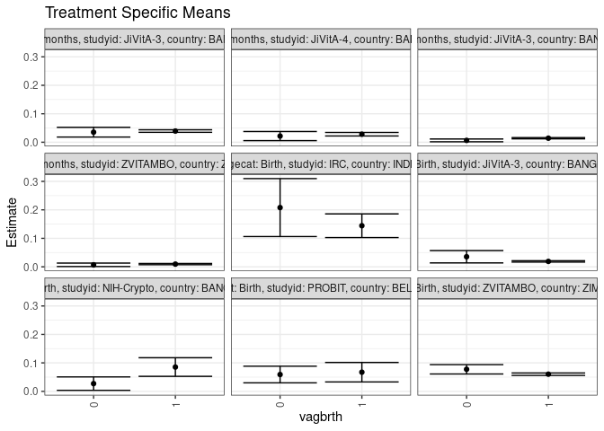

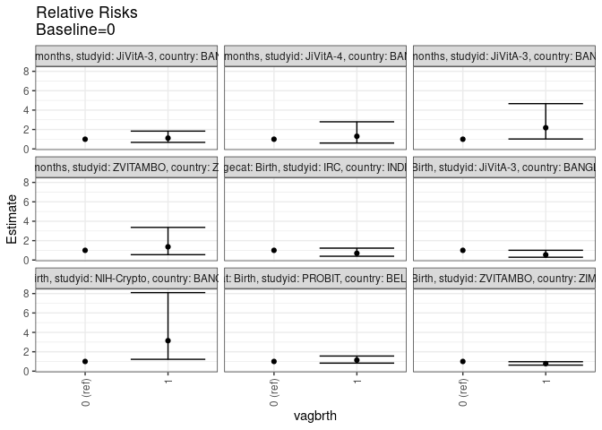

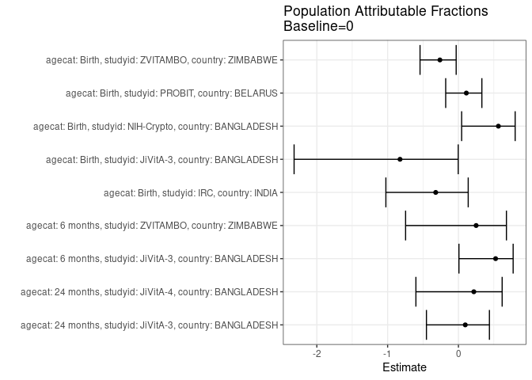

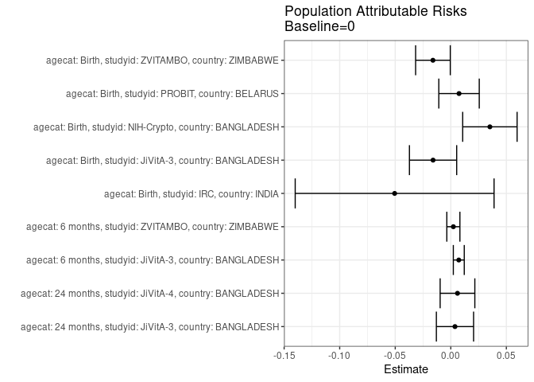

## Results Table

### Parameter: TSM

| agecat | studyid | country | intervention_level | baseline_level | estimate | ci_lower | ci_upper |
| --- | --- | --- | --- | --- | --- | --- | --- |
| Birth | IRC | INDIA | 0 | NA | 0.2079847 | 0.1062196 | 0.3097499 |
| Birth | IRC | INDIA | 1 | NA | 0.1442982 | 0.1027409 | 0.1858556 |
| Birth | JiVitA-3 | BANGLADESH | 0 | NA | 0.0353140 | 0.0136614 | 0.0569665 |
| Birth | JiVitA-3 | BANGLADESH | 1 | NA | 0.0189240 | 0.0165254 | 0.0213226 |
| Birth | NIH-Crypto | BANGLADESH | 0 | NA | 0.0271739 | 0.0036559 | 0.0506919 |
| Birth | NIH-Crypto | BANGLADESH | 1 | NA | 0.0854093 | 0.0526957 | 0.1181228 |
| Birth | PROBIT | BELARUS | 0 | NA | 0.0590966 | 0.0298736 | 0.0883196 |
| Birth | PROBIT | BELARUS | 1 | NA | 0.0673054 | 0.0331200 | 0.1014909 |
| Birth | ZVITAMBO | ZIMBABWE | 0 | NA | 0.0774813 | 0.0610866 | 0.0938760 |
| Birth | ZVITAMBO | ZIMBABWE | 1 | NA | 0.0603313 | 0.0560109 | 0.0646516 |
| 6 months | JiVitA-3 | BANGLADESH | 0 | NA | 0.0065116 | 0.0016099 | 0.0114134 |
| 6 months | JiVitA-3 | BANGLADESH | 1 | NA | 0.0142035 | 0.0120341 | 0.0163728 |
| 6 months | ZVITAMBO | ZIMBABWE | 0 | NA | 0.0069348 | 0.0008770 | 0.0129926 |
| 6 months | ZVITAMBO | ZIMBABWE | 1 | NA | 0.0094609 | 0.0073007 | 0.0116210 |
| 24 months | JiVitA-3 | BANGLADESH | 0 | NA | 0.0352791 | 0.0181846 | 0.0523737 |
| 24 months | JiVitA-3 | BANGLADESH | 1 | NA | 0.0392586 | 0.0347708 | 0.0437465 |
| 24 months | JiVitA-4 | BANGLADESH | 0 | NA | 0.0216718 | 0.0056736 | 0.0376701 |
| 24 months | JiVitA-4 | BANGLADESH | 1 | NA | 0.0282225 | 0.0220464 | 0.0343986 |

### Parameter: E(Y)

| agecat | studyid | country | intervention_level | baseline_level | estimate | ci_lower | ci_upper |
| --- | --- | --- | --- | --- | --- | --- | --- |
| Birth | IRC | INDIA | NA | NA | 0.1574344 | 0.1188345 | 0.1960344 |
| Birth | JiVitA-3 | BANGLADESH | NA | NA | 0.0193495 | 0.0169634 | 0.0217355 |
| Birth | NIH-Crypto | BANGLADESH | NA | NA | 0.0623656 | 0.0403628 | 0.0843684 |
| Birth | PROBIT | BELARUS | NA | NA | 0.0665123 | 0.0333611 | 0.0996634 |
| Birth | ZVITAMBO | ZIMBABWE | NA | NA | 0.0614172 | 0.0572600 | 0.0655744 |
| 6 months | JiVitA-3 | BANGLADESH | NA | NA | 0.0137085 | 0.0116390 | 0.0157780 |
| 6 months | ZVITAMBO | ZIMBABWE | NA | NA | 0.0092450 | 0.0072027 | 0.0112873 |
| 24 months | JiVitA-3 | BANGLADESH | NA | NA | 0.0390415 | 0.0347089 | 0.0433741 |
| 24 months | JiVitA-4 | BANGLADESH | NA | NA | 0.0276946 | 0.0218340 | 0.0335552 |

### Parameter: RR

| agecat | studyid | country | intervention_level | baseline_level | estimate | ci_lower | ci_upper |
| --- | --- | --- | --- | --- | --- | --- | --- |
| Birth | IRC | INDIA | 0 | 0 | 1.0000000 | 1.0000000 | 1.0000000 |
| Birth | IRC | INDIA | 1 | 0 | 0.6937925 | 0.3928334 | 1.2253236 |
| Birth | JiVitA-3 | BANGLADESH | 0 | 0 | 1.0000000 | 1.0000000 | 1.0000000 |
| Birth | JiVitA-3 | BANGLADESH | 1 | 0 | 0.5358782 | 0.2853979 | 1.0061933 |
| Birth | NIH-Crypto | BANGLADESH | 0 | 0 | 1.0000000 | 1.0000000 | 1.0000000 |
| Birth | NIH-Crypto | BANGLADESH | 1 | 0 | 3.1430605 | 1.2198971 | 8.0980841 |
| Birth | PROBIT | BELARUS | 0 | 0 | 1.0000000 | 1.0000000 | 1.0000000 |
| Birth | PROBIT | BELARUS | 1 | 0 | 1.1389049 | 0.8310463 | 1.5608089 |
| Birth | ZVITAMBO | ZIMBABWE | 0 | 0 | 1.0000000 | 1.0000000 | 1.0000000 |
| Birth | ZVITAMBO | ZIMBABWE | 1 | 0 | 0.7786558 | 0.6227652 | 0.9735689 |
| 6 months | JiVitA-3 | BANGLADESH | 0 | 0 | 1.0000000 | 1.0000000 | 1.0000000 |
| 6 months | JiVitA-3 | BANGLADESH | 1 | 0 | 2.1812449 | 1.0194849 | 4.6668949 |
| 6 months | ZVITAMBO | ZIMBABWE | 0 | 0 | 1.0000000 | 1.0000000 | 1.0000000 |
| 6 months | ZVITAMBO | ZIMBABWE | 1 | 0 | 1.3642561 | 0.5530721 | 3.3651933 |
| 24 months | JiVitA-3 | BANGLADESH | 0 | 0 | 1.0000000 | 1.0000000 | 1.0000000 |
| 24 months | JiVitA-3 | BANGLADESH | 1 | 0 | 1.1128008 | 0.6757006 | 1.8326545 |
| 24 months | JiVitA-4 | BANGLADESH | 0 | 0 | 1.0000000 | 1.0000000 | 1.0000000 |
| 24 months | JiVitA-4 | BANGLADESH | 1 | 0 | 1.3022679 | 0.6065679 | 2.7958972 |

### Parameter: PAR

| agecat | studyid | country | intervention_level | baseline_level | estimate | ci_lower | ci_upper |
| --- | --- | --- | --- | --- | --- | --- | --- |
| Birth | IRC | INDIA | 0 | NA | -0.0505503 | -0.1400411 | 0.0389404 |
| Birth | JiVitA-3 | BANGLADESH | 0 | NA | -0.0159645 | -0.0372274 | 0.0052983 |
| Birth | NIH-Crypto | BANGLADESH | 0 | NA | 0.0351917 | 0.0107070 | 0.0596764 |
| Birth | PROBIT | BELARUS | 0 | NA | 0.0074157 | -0.0107907 | 0.0256221 |
| Birth | ZVITAMBO | ZIMBABWE | 0 | NA | -0.0160641 | -0.0316627 | -0.0004655 |
| 6 months | JiVitA-3 | BANGLADESH | 0 | NA | 0.0071968 | 0.0022767 | 0.0121170 |
| 6 months | ZVITAMBO | ZIMBABWE | 0 | NA | 0.0023102 | -0.0035716 | 0.0081920 |
| 24 months | JiVitA-3 | BANGLADESH | 0 | NA | 0.0037624 | -0.0129823 | 0.0205071 |
| 24 months | JiVitA-4 | BANGLADESH | 0 | NA | 0.0060228 | -0.0095887 | 0.0216342 |

### Parameter: PAF

| agecat | studyid | country | intervention_level | baseline_level | estimate | ci_lower | ci_upper |
| --- | --- | --- | --- | --- | --- | --- | --- |
| Birth | IRC | INDIA | 0 | NA | -0.3210882 | -1.0247539 | 0.1380315 |
| Birth | JiVitA-3 | BANGLADESH | 0 | NA | -0.8250628 | -2.3208896 | -0.0030006 |
| Birth | NIH-Crypto | BANGLADESH | 0 | NA | 0.5642804 | 0.0453422 | 0.8011313 |
| Birth | PROBIT | BELARUS | 0 | NA | 0.1114931 | -0.1798312 | 0.3308836 |
| Birth | ZVITAMBO | ZIMBABWE | 0 | NA | -0.2615572 | -0.5422929 | -0.0319224 |
| 6 months | JiVitA-3 | BANGLADESH | 0 | NA | 0.5249924 | 0.0071734 | 0.7727375 |
| 6 months | ZVITAMBO | ZIMBABWE | 0 | NA | 0.2498844 | -0.7462542 | 0.6777827 |
| 24 months | JiVitA-3 | BANGLADESH | 0 | NA | 0.0963685 | -0.4519141 | 0.4376046 |
| 24 months | JiVitA-4 | BANGLADESH | 0 | NA | 0.2174713 | -0.6006481 | 0.6174355 |